# R beginners learning tips

benjamini mpinga

2022-07-22

```r
require(tidyverse)
require(lubridate)
require(dplyr)
require(lubridate)
require(readxl)
require(janitor)
require(magrittr)
require(readr)
```

# Personal experience

In the beginning of almost every book i red concerning R Programming,it was both courageous and ambitious,well that is what exactly the authors need you to experience so that you might get started by hope and excitement.

Though it is good to read, especially when you are good at,but in my personal experience and you may take it as a piece of advice that is even best to have a **Mentor** rather than a **Roll model**.

## R Mentor vs R Roll model

**A Mentor** is a person well equiped/advanced in respect of this topic **(with R knowledge)** a person either present to your environment or who you can have access to reach in case you get stack or need more tips in your learning process.

On the other hand a **Roll model** is a person well equiped/advanced in R knowledge but the only help you can get from him/her is information through their writings or documentaries,though they may be usefully but also they may not solve all of your quick concerns.

I am not discouraging one from relay and spend time in books no!,but what i am trying to advice is that,through reading only or searching online contents you will find answers, but for beginners in R Programming Language it is better to have someone who can take you through obstacles,one that can spend sometimes with you introducing obvious expected challenges and prepare you to tackle them.

## R the right platfom

Another good news for beginners in R language is that,in your progress toward mastering it,you will get a wonderful experience…

- Coding skills
- Writing skills
- Generation of multiple format through a single document
- Document standard visualisation
- Data analysis skills
- Statistical knowledge and many others.

Imagine the the simplicity of preparing a single document on a platform that allows you to share it in multiple format such as **Pdf,Word, or html**!.but in R it is not an imaginations **it is what it is**.Good enough is that,even this book your reading is the product of R.

# Modern R

To get started you must install R and Rstudio together with all necessary required packages into your computer,may be you may wonder,**why R and Rstudio?**. Well R is a programming language and Rstudio is a platform,but together provides you a great working tools and invironnment.

## R Installation

RStudio is an integrated development environment, or IDE, for R programming. Download and install it from http://www.rstu dio.com/download.

## R Package installation

In R packages are very fundamental instrument therefor you need to install all the necessary packages before getting further. One main package is (**“tidyverse”**). tidyverse is an ecosystem of packages that focus on data entry,data manipulation,data modelling,data visualization(plott) and sharing of finding/insight derived from data analysis.

```
                         [ install.packages("tidyverse") ]
```

Packages in the tidyverse change fairly frequently. You can see if updates are available, and optionally install them, by running tidy verse_update().

Install tidyverse through this command and any other packages as you will find fit for your own focused area of field.

# Introduction to Data science in R programme

Data science is an exciting discipline that allows you to turn raw data into understanding, insight, and knowledge. The goal of R for Data Science is to help you learn the most important tools in R that will allow you to do data science.

Data science is a huge field, and there’s no way you can master it by reading a single book,so as i explained above it is more helpful if you get a mentor to lead you through obstacles.

## Data importation

First you must import your data into R. This typically means that you take data stored in a file, database, or web API, and load it into a data frame in R. If you can’t get your data into R, you can’t do data science on it!

## Tyding

Once you’ve imported your data, it is a good idea to tidy it. Tidying your data means storing it in a consistent form that matches the semantics of the dataset with the way it is stored. In brief, when your data is tidy, **each column is a variable, and each row is an observation**.

Tidy data is important because the consistent structure lets you focus your struggle on questions about the data, not fighting to get the data into the right form for different functions.

Once you have tidy data, a common first step is to transform it.Transformation includes narrowing in on observations of interest(like all people in one city, or all data from the last year), creating new variables that are functions of existing variables Together, tidying and transforming are called wrangling,because getting your data in a form that’s natural to work with often feels like a fight!

Once you have tidy data with the variables you need, there are two main engines of knowledge generation:

**visualization and modeling**.These have complementary strengths and weaknesses so any real analysis will iterate between them many times.

## Visualization

Visualization is a fundamentally human activity. A good visualization will show you things that you did not expect, or raise new questions about the data. A good visualization might also hint that you’re asking the wrong question, or you need to collect different data. Visualizations can surprise you, but don’t scale particularly well because they require a human to interpret them.

## Models

Models are complementary tools to visualization. Once you have made your questions sufficiently precise, you can use a model to answer them. Models are a fundamentally mathematical or computational tool, so they generally scale well. Even when they don’t, **it’s usually cheaper to buy more computers than it is to buy more brains!** But every model makes assumptions, and by its very nature a model cannot question its own assumptions. That means a model cannot fundamentally surprise you.

## Communication

The last step of data science is communication, an absolutely critical part of any data analysis project. It doesn’t matter how well your models and visualization have led you to understand the data unless you can also communicate your results to others.

# Rules of the game in R

Like any other game or language,in order to perform or being grammatical correct you have to apply the correct verb for a particular tense.as well as correct action for a specific environment.

The same applies to every programming language,for the better result of your data analysis you have to apply the correct package for a specific task,every package contains functions in which there are verbs that act that particular task.**(Lets focus on tidyverse)**.

## Data Transformation with dplyr

**Introduction**

Visualization is an important tool for insight generation, but it is rare that you get the data in exactly the right form you need. Often you’ll need to create some new variables or summaries, or maybe you just want to rename the variables or reorder the observations in order to make the data a little easier to work with.

focus on how to use the dplyr package,another core member of the tidyverse.

**VERBS**

- (filter()).
- (arrange()).
- (select()).
- (mutate()).
- (summarize()).
- (group_by()).

These six functions provide the verbs for data manipulation.

## Filter

Filter is one of the verb in tidyverse which usually deals with **rows(records)** only in your data frame,the main thing it does is to pick observations by their volume depends on the result you intend to achieve. **(==,>,<)**.

## Select

Select is one of the verb in tidyverse which usually deals with **collum (variables)** only in your table data frame,what it does is to select the variables by their names depends on the result you intend to achieve.**(=)**.

## Arrange

Arrange is one of the verb in tidyverse which usually Reorder the **rows(Records)** of your data frame to allow you get result you intend.

## Summarize

Summarize is one of the verb in tidyverse which Collapse many values down to a single summary

## Group by

Group by is one of the verb in tidyverse used in changes of the scope of each function from operating on the entire data frame to operating on it group-by-group.

## Mutate

Mutate is one of the verb in tidyverse Create new variables with functions of existing variables.

> **NOTE**: *All data frame contain Row and Collum,therefore rows have to contains Records in it,while colums have to contain variables in it (names)*.

**therefor to successfully implement the above said verbs, you will have to ensure the following…**

- firstlly you will have to be very clear on What kind of result is need, this depends on the data questions.
- Secondly is to understand data provided before importing it to R, for analysis. (To peruse them and see if they are tidy or messy data).
- Thirdly if they are tidy, and you have already understand a question, then you need to know which kind of verb you can use to get the result. but if data are messy, then you will need to correct them before importation or if already imported then require tidying before further steps.

**abbreviation**

- **int** stands for integers.
- **dbl** stands for doubles, or real numbers.
- **chr** stands for character vectors, or strings.
- **dttm** stands for date-times (a date + a time).

R provides the standard suite: >, >=, <, <=, != (not equal), and == (equal).When you’re starting out with R, the easiest mistake to make is to use = instead of == when testing for equality.

**The rules are………**

- **“Happy families are all alike; every unhappy family is unhappy in its own way.” ––- Leo Tolstoy**
- **“Tidy data sets are all alike, but every messy data set is messy in its own way.” ––- Hadley Wickham**

# DATA IMPOTATION.

As we have seen in the beginning of this book,in order to do activities in R,you need data, without data R is like meaningless application in your computer.So since data work as a fuel in R, step one you need to know how to import data into it.

## Step 1.

You have to know what kind of data you have before importing it into R. Data are usually in different extension, then you have to ensure you put your data in the right extension and in the specific directory.

**Eg; xls,csv etc…….**

## Step 2.

On your computer open R studio, programing is usually done on console. But in the bellow demo will work on the environment.

*Procedures.* My data names is csv (BUDGET DAUDI HEALTH CENTRE)excel.

open chunk..then in the chunk call the required package for data importation, for my data are in Excel and csv extension so i will use **(tidyverse and read_excel and read_csv).**So i begin with csv extension.

# DATA TYPE.

After knowing the first procedure of entering your data into R, then before moving to data manipulation,you have to know what kind of data they are,therefor here we focus on the types of data.

**Shortly we have several types of data type….**

1. ` Character — these type of data are strings/names.
2. ` Double/Numeric — these type are measurable data/decimals.
3. ` Integer — these are numbered data/countable (0 to 9).
4. ` Factor — these data are categorical/level.
5. ` Date — Basically deal with dmy.

# R and the Tidyverse

This chapter provides an introduction to data science and the R programming language. The goal here is to get your hands dirty right from the start! We will walk through an entire data analysis, and along the way introduce different types of data analysis question, some fundamental programming concepts in R, and the basics of loading, cleaning, and visualizing data. In the following chapters, we will dig into each of these steps in much more detail; but for now, let’s jump in to see how much we can do with data science!

1. ` character
2. ` numeric
3. ` integer
4. ` factor
5. ` date
6. ` logical

## character vector.

```r
names = c("grace", "daniel", "collins", "ethan", "benjunior")
names
```

```
## [1] "grace"     "daniel"    "collins"   "ethan"     "benjunior"
```

lets test if our vector is character

```r
is.character(names); is.vector(names); is.factor(names);class(names)
```

```
## [1] TRUE
```

```
## [1] TRUE
```

```
## [1] FALSE
```

```
## [1] "character"
```

## integer vector

```r
food = c(1,2,3,4,5)
food
```

```
## [1] 1 2 3 4 5
```

lets test if our food is integer vector

```r
is.integer(food); is.vector(food); is.character(food); is.numeric(food); is.factor(food)
```

```
## [1] FALSE
```

```
## [1] TRUE
```

```
## [1] FALSE
```

```
## [1] TRUE
```

```
## [1] FALSE
```

now as we may see our answers show that our integer vector is FALSE, and Numeric is TRUE, then we have to change from numeric to integer.

```r
food = as.integer(food)
food
```

```
## [1] 1 2 3 4 5
```

```r
is.integer(food)
```

```
## [1] TRUE
```

You may wonder why our integer resulted to numeric while we had created an integer vector?. well the reason is that in R, most of its understanding data is Numeric, therefor is so obvious to find same result over and over.

## Numeric vector

```r
age = c(11.5, 5.2, 5.3, 3.2, 1.2)
age
```

```
## [1] 11.5  5.2  5.3  3.2  1.2
```

let’s test our numeric vector

```r
is.numeric(age); is.integer(age); is.character(age); class(age)
```

```
## [1] TRUE
```

```
## [1] FALSE
```

```
## [1] FALSE
```

```
## [1] "numeric"
```

## factor vector

```r
gender = c("female", "male", "male", "male", "male")
gender
```

```
## [1] "female" "male"   "male"   "male"   "male"
```

let’s test is our vector factor?

```r
class(gender); is.integer(gender); is.numeric(gender); is.factor("gender")
```

```
## [1] "character"
```

```
## [1] FALSE
```

```
## [1] FALSE
```

```
## [1] FALSE
```

as shows the above result, our factor has appeared as character, so let’s convert it to factor.

```r
gender = as.factor(gender)
gender
```

```
## [1] female male   male   male   male
## Levels: female male
```

```r
class(gender); is.integer(gender); is.factor(gender); is.character(gender)
```

```
## [1] "factor"
```

```
## [1] FALSE
```

```
## [1] TRUE
```

```
## [1] FALSE
```

```r
levels(gender)
```

```
## [1] "female" "male"
```

## date vector

```r
birth = c(dmy(01022011), dmy(01062017), dmy(01052017), dmy(01062019), dmy(01062021))
birth
```

```
## [1] "2011-02-01" "2017-06-01" "2017-05-01" "2019-06-01" "2021-06-01"
```

As we can see our date vector shows date, month and year, now let’s test it.

```r
class(birth); is.integer(birth);is.numeric(birth);is.Date(birth);is.vector(birth)
```

```
## [1] "Date"
```

```
## [1] FALSE
```

```
## [1] FALSE
```

```
## [1] TRUE
```

```
## [1] FALSE
```

## Sequence

```r
seq(0:100)
```

```
##   [1]   1   2   3   4   5   6   7   8   9  10  11  12  13  14  15  16  17  18
##  [19]  19  20  21  22  23  24  25  26  27  28  29  30  31  32  33  34  35  36
##  [37]  37  38  39  40  41  42  43  44  45  46  47  48  49  50  51  52  53  54
##  [55]  55  56  57  58  59  60  61  62  63  64  65  66  67  68  69  70  71  72
##  [73]  73  74  75  76  77  78  79  80  81  82  83  84  85  86  87  88  89  90
##  [91]  91  92  93  94  95  96  97  98  99 100 101
```

```r
number = seq(from = 0, to = 100, by = 2)
number
```

```
##  [1]   0   2   4   6   8  10  12  14  16  18  20  22  24  26  28  30  32  34  36
## [20]  38  40  42  44  46  48  50  52  54  56  58  60  62  64  66  68  70  72  74
## [39]  76  78  80  82  84  86  88  90  92  94  96  98 100
```

```r
length(number)
```

```
## [1] 51
```

## Index

```r
number[51]
```

```
## [1] 100
```

```r
names[3]
```

```
## [1] "collins"
```

```r
names[2:5]
```

```
## [1] "daniel"    "collins"   "ethan"     "benjunior"
```

## Repeat an element in a vector

```r
rep(names,each = 3)
```

```
##  [1] "grace"     "grace"     "grace"     "daniel"    "daniel"    "daniel"
##  [7] "collins"   "collins"   "collins"   "ethan"     "ethan"     "ethan"
## [13] "benjunior" "benjunior" "benjunior"
```

```r
rep(names,times = 3)
```

```
##  [1] "grace"     "daniel"    "collins"   "ethan"     "benjunior" "grace"
##  [7] "daniel"    "collins"   "ethan"     "benjunior" "grace"     "daniel"
## [13] "collins"   "ethan"     "benjunior"
```

## Adding an index in a vector

```r
names [6] = "amani"
names
```

```
## [1] "grace"     "daniel"    "collins"   "ethan"     "benjunior" "amani"
```

```r
names [6] =  "amani"
names
```

```
## [1] "grace"     "daniel"    "collins"   "ethan"     "benjunior" "amani"
```

## removing an index in vector

```r
names = names[1:5]
names
```

```
## [1] "grace"     "daniel"    "collins"   "ethan"     "benjunior"
```

```r
length(names); length(food); length(age); length(birth)
```

```
## [1] 5
```

```
## [1] 5
```

```
## [1] 5
```

```
## [1] 5
```

```r
data.frame(names, birth, age, food, gender )
```

```
##       names      birth  age food gender
## 1     grace 2011-02-01 11.5    1 female
## 2    daniel 2017-06-01  5.2    2   male
## 3   collins 2017-05-01  5.3    3   male
## 4     ethan 2019-06-01  3.2    4   male
## 5 benjunior 2021-06-01  1.2    5   male
```

```r
watoto = data.frame(names, birth, age, food, gender)
watoto
```

```
##       names      birth  age food gender
## 1     grace 2011-02-01 11.5    1 female
## 2    daniel 2017-06-01  5.2    2   male
## 3   collins 2017-05-01  5.3    3   male
## 4     ethan 2019-06-01  3.2    4   male
## 5 benjunior 2021-06-01  1.2    5   male
```

```r
watoto %>% filter(gender == "female")
```

```
##   names      birth  age food gender
## 1 grace 2011-02-01 11.5    1 female
```

## fillter

```r
watoto %>% filter(gender == "male")
```

```
##       names      birth age food gender
## 1    daniel 2017-06-01 5.2    2   male
## 2   collins 2017-05-01 5.3    3   male
## 3     ethan 2019-06-01 3.2    4   male
## 4 benjunior 2021-06-01 1.2    5   male
```

```r
watoto %>% filter(age == 5.3)
```

```
##     names      birth age food gender
## 1 collins 2017-05-01 5.3    3   male
```

```r
watoto %>% filter(age < 4)
```

```
##       names      birth age food gender
## 1     ethan 2019-06-01 3.2    4   male
## 2 benjunior 2021-06-01 1.2    5   male
```

```r
watoto %>% filter(age >3)
```

```
##     names      birth  age food gender
## 1   grace 2011-02-01 11.5    1 female
## 2  daniel 2017-06-01  5.2    2   male
## 3 collins 2017-05-01  5.3    3   male
## 4   ethan 2019-06-01  3.2    4   male
```

```r
watoto %>% filter(food < 2)
```

```
##   names      birth  age food gender
## 1 grace 2011-02-01 11.5    1 female
```

```r
watoto %>% filter(age < 5)
```

```
##       names      birth age food gender
## 1     ethan 2019-06-01 3.2    4   male
## 2 benjunior 2021-06-01 1.2    5   male
```

```r
watoto %>% filter(birth == dmy(01022011) | birth == dmy(01062019))
```

```
##   names      birth  age food gender
## 1 grace 2011-02-01 11.5    1 female
## 2 ethan 2019-06-01  3.2    4   male
```

```r
watoto %>% filter(birth == dmy(01022011) & gender == "female")
```

```
##   names      birth  age food gender
## 1 grace 2011-02-01 11.5    1 female
```

## Select

```r
watoto %>% select(names,gender)
```

```
##       names gender
## 1     grace female
## 2    daniel   male
## 3   collins   male
## 4     ethan   male
## 5 benjunior   male
```

```r
watoto %>% select(1,4)
```

```
##       names food
## 1     grace    1
## 2    daniel    2
## 3   collins    3
## 4     ethan    4
## 5 benjunior    5
```

```r
watoto %>% select(1,5)
```

```
##       names gender
## 1     grace female
## 2    daniel   male
## 3   collins   male
## 4     ethan   male
## 5 benjunior   male
```

```r
watoto %>% select(1:4)
```

```
##       names      birth  age food
## 1     grace 2011-02-01 11.5    1
## 2    daniel 2017-06-01  5.2    2
## 3   collins 2017-05-01  5.3    3
## 4     ethan 2019-06-01  3.2    4
## 5 benjunior 2021-06-01  1.2    5
```

## arrange

```r
watoto %>% arrange(names,age,gender)
```

```
##       names      birth  age food gender
## 1 benjunior 2021-06-01  1.2    5   male
## 2   collins 2017-05-01  5.3    3   male
## 3    daniel 2017-06-01  5.2    2   male
## 4     ethan 2019-06-01  3.2    4   male
## 5     grace 2011-02-01 11.5    1 female
```

```r
watoto %>% arrange(names)
```

```
##       names      birth  age food gender
## 1 benjunior 2021-06-01  1.2    5   male
## 2   collins 2017-05-01  5.3    3   male
## 3    daniel 2017-06-01  5.2    2   male
## 4     ethan 2019-06-01  3.2    4   male
## 5     grace 2011-02-01 11.5    1 female
```

```r
watoto %>% arrange(watoto)
```

```
##       names      birth  age food gender
## 1 benjunior 2021-06-01  1.2    5   male
## 2   collins 2017-05-01  5.3    3   male
## 3    daniel 2017-06-01  5.2    2   male
## 4     ethan 2019-06-01  3.2    4   male
## 5     grace 2011-02-01 11.5    1 female
```

```r
watoto %>% arrange(age)
```

```
##       names      birth  age food gender
## 1 benjunior 2021-06-01  1.2    5   male
## 2     ethan 2019-06-01  3.2    4   male
## 3    daniel 2017-06-01  5.2    2   male
## 4   collins 2017-05-01  5.3    3   male
## 5     grace 2011-02-01 11.5    1 female
```

```r
watoto %>% arrange(gender)
```

```
##       names      birth  age food gender
## 1     grace 2011-02-01 11.5    1 female
## 2    daniel 2017-06-01  5.2    2   male
## 3   collins 2017-05-01  5.3    3   male
## 4     ethan 2019-06-01  3.2    4   male
## 5 benjunior 2021-06-01  1.2    5   male
```

```r
watoto %>% arrange(birth)
```

```
##       names      birth  age food gender
## 1     grace 2011-02-01 11.5    1 female
## 2   collins 2017-05-01  5.3    3   male
## 3    daniel 2017-06-01  5.2    2   male
## 4     ethan 2019-06-01  3.2    4   male
## 5 benjunior 2021-06-01  1.2    5   male
```

```r
watoto %>% arrange(desc(food))
```

```
##       names      birth  age food gender
## 1 benjunior 2021-06-01  1.2    5   male
## 2     ethan 2019-06-01  3.2    4   male
## 3   collins 2017-05-01  5.3    3   male
## 4    daniel 2017-06-01  5.2    2   male
## 5     grace 2011-02-01 11.5    1 female
```

```r
watoto %>% arrange(food)
```

```
##       names      birth  age food gender
## 1     grace 2011-02-01 11.5    1 female
## 2    daniel 2017-06-01  5.2    2   male
## 3   collins 2017-05-01  5.3    3   male
## 4     ethan 2019-06-01  3.2    4   male
## 5 benjunior 2021-06-01  1.2    5   male
```

## Mutate

```r
watoto %>% mutate(sport = c("footbal", "footbal","voleybal", "basketbal", "netbal"))
```

```
##       names      birth  age food gender     sport
## 1     grace 2011-02-01 11.5    1 female   footbal
## 2    daniel 2017-06-01  5.2    2   male   footbal
## 3   collins 2017-05-01  5.3    3   male  voleybal
## 4     ethan 2019-06-01  3.2    4   male basketbal
## 5 benjunior 2021-06-01  1.2    5   male    netbal
```

# DATA MANIPULATION.

In R we use different approach when it comes to data manipulation, different from other extensions, so once given data, the first thing to understand is its type.

```r
raw = read_excel("e:/MY STAFS/rlaguage//Tamisemi/Primary Enrolment by Age and Sex,2021.xls")
```

The data above are not in tidy form, therefor we have to dity them before using them. Now i will not write every step of the process but you can see the function in the chunk as i progressively come to the results.

## Our data is calle raw.

In this particular step we are going to rename our column, and remove column 1,28 and 29,there for we shall remain with 26 column.*Now our data is called moja*.We shall use function *“clean names”* of *“Janitor package”*.

```r
moja = raw %>% clean_names() %>% select(-c(1,28,29))
```

Now let’s rename our **7 to 26 column** because they are not well arranged, as we can see age and gender are both in same column, in order to put it clear and easier for analysis then we must separate them. But yet the data frame shows that ages of kids are not specified, some are actul and some are unspecific, therefore we are going to predict some values that can fit in analysis,*where age is below 6 we shall put 5, and where is above 13 we shall put 14*, then we will specify in detail in an output. Here we shall use pivot function of janitor package which is in tidyverse package.

```r
mbili = moja %>% pivot_longer(names_to = "kids", values_to = "number", cols = 7:26) %>%
  mutate(gender = c("boys", "girls") %>% rep(times = 185460),
         age = seq(5, 14, 1) %>% rep(each = 2) %>% rep(times = 18546))
```

Now we deselect kids column and registration number column.

```r
tatu = mbili %>% select(-c(5,7))
```

Now that we know how we can create data in R studio, it is true that most of the time you will be given data from outsource. Then to deal with them you have to save them in your computer. as we have already that R without data is just an Application. Now lets jump strait to your computer and see how you can get data from your computer’s file **(directory)** to R studio.

# DATA IMPORTATION.

Data importation in R refeers to the process of calling your data from the directory (file) in your computer into the R studio where you intend to do your analysis.

##lets see how we call our data from our directory as a first step to approach your instict.

```r
read_csv("e:/MY STAFS/rlaguage//BUDGET DAUDI HEALTH CENTRE 2022.csv")
```

```
## -------------------------------------------------------- Delimiter: "," chr
## (6): TARGET, ACTIVITY, GSF CODE, Unit of measure, TOTAL, Source of Fund dbl
## (2): Quantity, frequencer lgl (1): ...10
```

```
## # A tibble: 18 x 11
##    TARGET    ACTIV~1 GSF C~2 Unit ~3 Quant~4 frequ~5 unit ~6 TOTAL Sourc~7 ...10
##    <chr>     <chr>   <chr>   <chr>     <dbl>   <dbl>   <dbl> <chr> <chr>   <lgl>
##  1 Shortage~ To sup~ Medica~ Kits          6       5  1.27e4 380,~ OC      NA
##  2 <NA>      <NA>    Drugs ~ Kits          6       5  4.23e4 1,26~ <NA>    NA
##  3 <NA>      <NA>    Hospit~ Kits          6       5  8.45e3 253,~ <NA>    NA
##  4 <NA>      <NA>    PPMof ~ Kits          6       5  4.23e3 126,~ <NA>    NA
##  5 <NA>      <NA>    Dental~ Kits          6       5  8.45e3 253,~ <NA>    NA
##  6 <NA>      <NA>    Labora~ Kits          6       5  8.45e3 253,~ <NA>    NA
##  7 <NA>      <NA>    <NA>    <NA>         NA      NA NA      2,53~ <NA>    NA
##  8 <NA>      To sup~ wire    metre         1       1  1.31e6 1309~ <NA>    NA
##  9 Organiza~ To pro~ extra ~ Person        0       1  1.65e5 -     OC      NA
## 10 <NA>      <NA>    Leave ~ Person        3       1  1.2 e5 360,~ <NA>    NA
## 11 <NA>      <NA>    Medica~ Person        2       4  1   e5 800,~ <NA>    NA
## 12 <NA>      <NA>    Unifor~ Person        2       1  1.2 e5 240,~ <NA>    NA
## 13 <NA>      <NA>    Burial~ Person        2       1  1   e6 2000~ <NA>    NA
## 14 <NA>      <NA>    Statio~ Each          0       4  1.61e4 0     <NA>    NA
## 15 <NA>      <NA>    <NA>    <NA>         NA      NA NA      3,40~ <NA>    NA
## 16 <NA>      <NA>    <NA>    <NA>         NA      NA NA      7,24~ <NA>    NA
## 17 <NA>      <NA>    <NA>    <NA>         NA      NA NA      <NA>  <NA>    NA
## 18 <NA>      <NA>    <NA>    <NA>         NA      NA NA      -     <NA>    NA
## # ... with 1 more variable: ...11 <dbl>, and abbreviated variable names
## #   1: ACTIVITY, 2: `GSF CODE`, 3: `Unit of measure`, 4: Quantity,
## #   5: frequencer, 6: `unit price`, 7: `Source of Fund`
```

the above tables are showing the importation of data from your directory into R, using csv extension.

```r
read_xlsx("e:/MY STAFS/rlaguage//BUDGET DAUDI HEALTH CENTRE 2022.xlsx")
```

```
## # A tibble: 32 x 10
##    TARGET   ACTIV~1 GSF C~2 Unit ~3 Quant~4 frequ~5 unit ~6  TOTAL Sourc~7 ...10
##    <chr>    <chr>   <chr>   <chr>     <dbl>   <dbl>   <dbl>  <dbl> <chr>   <dbl>
##  1 Shortag~ To sup~ Medica~ Kits          6       5   52500 1.58e6 USER F~    NA
##  2 <NA>     <NA>    Drugs ~ Kits          6       5  175000 5.25e6 <NA>       NA
##  3 <NA>     <NA>    Hospit~ Kits          6       5   35000 1.05e6 <NA>       NA
##  4 <NA>     <NA>    PPMof ~ Kits          6       5   50000 5.25e5 <NA>       NA
##  5 <NA>     <NA>    Dental~ Kits          6       5   35000 1.05e6 <NA>       NA
##  6 <NA>     <NA>    Labora~ Kits          6       5   35000 1.05e6 <NA>       NA
##  7 <NA>     <NA>    <NA>    <NA>         NA      NA      NA 1.05e7 <NA>       NA
##  8 Organiz~ To pro~ Water ~ bills        64      12    2500 1.92e6 USER F~    NA
##  9 <NA>     <NA>    Electr~ bills      1200       6     400 2.88e6 <NA>       NA
## 10 <NA>     <NA>    Per di~ person        5       5   80000 2   e6 <NA>       NA
## # ... with 22 more rows, and abbreviated variable names 1: ACTIVITY,
## #   2: `GSF CODE`, 3: `Unit of measure`, 4: Quantity, 5: frequencer,
## #   6: `unit price`, 7: `Source of Fund`
```

the above tables are showing the importation of data from your directory into R, using Xlsx extension.

# STATISTICS

**Statistics Definition:**

Statistics is a branch of Maths that deals with every aspect of the data.

## Statistics knoledge

Statistical knowledge helps to choose the proper method of collecting data and employ those samples in the correct analysis process in order to effectively produce the results.

In short, statistics is a crucial process which helps to make the decision based on the data.

**What is Statistics in Maths?**

In Mathematics, statistics concerns the collection of data, organisation, interpretation, analysis and data presentation.

### Frequently Asked Questions on Statistics Definition

**What is Statistics?**

Statistics is the branch of mathematics for collecting, analysing and interpreting data. Statistics can be used to predict the future, determine the probability that a specific event will happen, or help answer questions about a survey. Statistics is used in many different fields such as business, medicine, biology, psychology and social sciences.

An example of statistical analysis is when we have to determine the number of people in a town who watch TV out of the total population in the town. The small group of people is called the sample here, which is taken from the population.

**What are the types of statistics?**

- **descriptive**
- **Inferential**

Inferential Statistics – Based on the data sample taken from the population, inferential statistics makes the predictions and inferences.

Both types of statistics are equally employed in the field of statistical analysis. Learn in detail descriptive and inferential statistics here at BYJU’S.

**The important characteristics of Statistics are as follows:**

- Statistics are numerically expressed.
- It has an aggregate of facts
- Data are collected in systematic order
- It should be comparable to each other
- Data are collected for a planned purpose

**The importance of statistics are:**

- Statistics helps in gathering information about the appropriate quantitative data
- It depicts the complex data in graphical form, tabular form and in diagrammatic representation to understand it easily
- It provides the exact description and a better understanding
- It helps in designing the effective and proper planning of the statistical inquiry in any field
- It gives valid inferences with the reliability measures about the population parameters from the sample data
- It helps to understand the variability pattern through the quantitative observations

**Statistics Example**

There are two types of statistics.

One type is called descriptive statistics, which focuses on summarizing data.

Another type is called inferential statistics, which focuses on making conclusions about populations based on samples.

**Why are statistics vital?**

Statistics is an important field because it helps us understand the general trends and patterns in a given data set. Statistics can be used for analysing data and drawing conclusions from it. It can also be used for making predictions about future events and behaviours. Statistics also help us understand how things are changing over time.

The main purpose of using statistics is to plan the collected data in terms of experimental designs and statistical surveys. Statistics is considered a mathematical science that works with numerical data.

**What are the uses of statistics in real life?**

Statistics is an integral part of our lives. It is used in the workplace and everyday life. In the workplace, statistics are often used to analyse what works best for a company’s marketing strategy or how to distribute work among employees. In daily life, statistics can be used to analyse what food you should buy at the grocery store or how much money you spend on purchasing each week. Statistics are everywhere, and they help us make sense of the world around us.

**What are the most important concepts covered in statistics?**

The most important concepts covered in Statistics include *mean, median, mode, range, and standard deviation.*

Mean and Median in statistics usually measure the median/mean value, but their application depend on the sample’s nature.

- **Median** To calculate median value when your data values are mostly alike but some few values have big difference from the other either High or Low. The purpose is to avoid the high or low values to affect the result. Basically for numeric data.
- **Mean**
- **Mode** is to calculate the repeat of the same value in a data set.
- **Standard deviation** is calculation to measure where your data deviate from the normal value.

# Central Limit Theory (CLT)

In statistics the central limit theory means the value on which majority of population falls. It simply states that The distribution approaches normal, as the samples get larger. therefor it is recommended that to attain doubtless results you are required to collect at least >/= of 30% samples of the population.

This theory of central limit usually shown through continuous plots such as Histogram and density. This is due to their nature. On the figure below we are going to see the example of central limit theory in visualization.

In this study we will see how statistics works in real life, and how useful it is in every day’s decision making. By applying a proper and correct method in collecting/recording samples, analyzing, interpreting and sharing of findings is always a best way to reach the right decisions, especially for decision makers, weather in family level.

## Data sample

**Temperature at Kigamboni.**

```r
sample1 = rnorm(n = 10, mean = 26, sd = 2) %>% as_tibble() %>% mutate(sample = "samp1")

sample2 = rnorm(n = 20, mean = 26, sd = 2) %>% as_tibble() %>% mutate(sample = "samp2")

sample3 = rnorm(n = 30, mean = 26, sd = 2) %>% as_tibble() %>% mutate(sample = "samp3")

sample4 = rnorm(n = 40, mean = 26, sd = 2) %>% as_tibble() %>% mutate(sample = "samp4")

sample5 = rnorm(n = 50, mean = 26, sd = 2) %>% as_tibble() %>% mutate(sample = "samp5")
```

How to bind different samples to a one dataset,you either combine rows or columns. We use the function **bind_rows/bind_col.**

```r
data.sample = bind_rows(sample1,
                        sample2,
                        sample3,
                        sample4,
                        sample5)
```

We have created different sample size and bind five samples together, we have used the function **binding_rows** to bind. We have named them **(data.sample)**. But these data are auto-generated from the system, so they change from time to time as you run your chunk.Therefor in order to permanently use them without changes, then you’ll need to save them in your directory.

Remember when you import data into R, we use the function **read_**. But to save generated data from the system to directory you are working from, you apply the function called **write_**, and you may save it in whatever extension you often use.

Hereunder is the function plus application to save the data generated from the system into the directory. Our new data will be called **datasample.** But we will put a comment so that a chunk not to run. but however i must show you how it is been applied when you want to save your data. We have saved our data in **csv** extension.

```r
#data.sample %>% write_csv("datasample.csv")
```

Now that our data are saved in the directory, then we must import them into R. So the bellow chunk is how we call for our data from our directory, and we give it a name **supa**.

```r
supa = read_csv("datasample.csv")
```

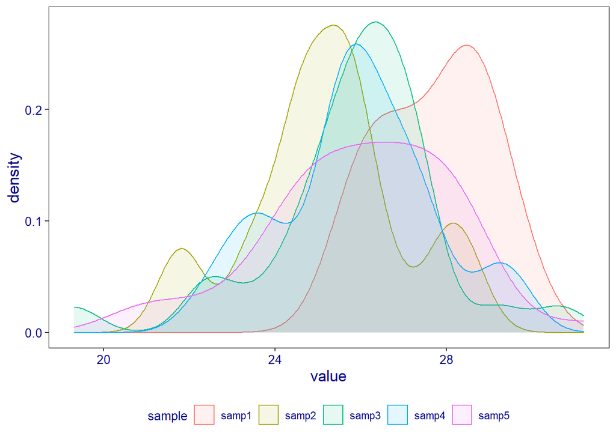

```r
supa %>%
  ggplot(aes(x = value, colour = sample, fill = sample))+
  geom_density(alpha = 0.1)+
  theme_bw()+theme(panel.grid.major = element_blank())+
  theme(panel.grid.minor = element_blank())+
  theme(legend.position = "bottom")+theme(axis.text.x = element_text(colour = "darkblue", size = 10),axis.text.y = element_text(colour = "darkblue", size = 10),axis.title = element_text(colour = "darkblue", size = 13),legend.text = element_text(colour = "darkblue"),legend.title = element_text(colour = "darkblue", size = 10))
```

above figure show all sample’s result together, it is easier to present samples result in one figure, but the main purpose is to be understandable. Therefor it may be a bit harder for a viewer to understand the above figure. So in such situation we can opt to present our figure in separate samples.

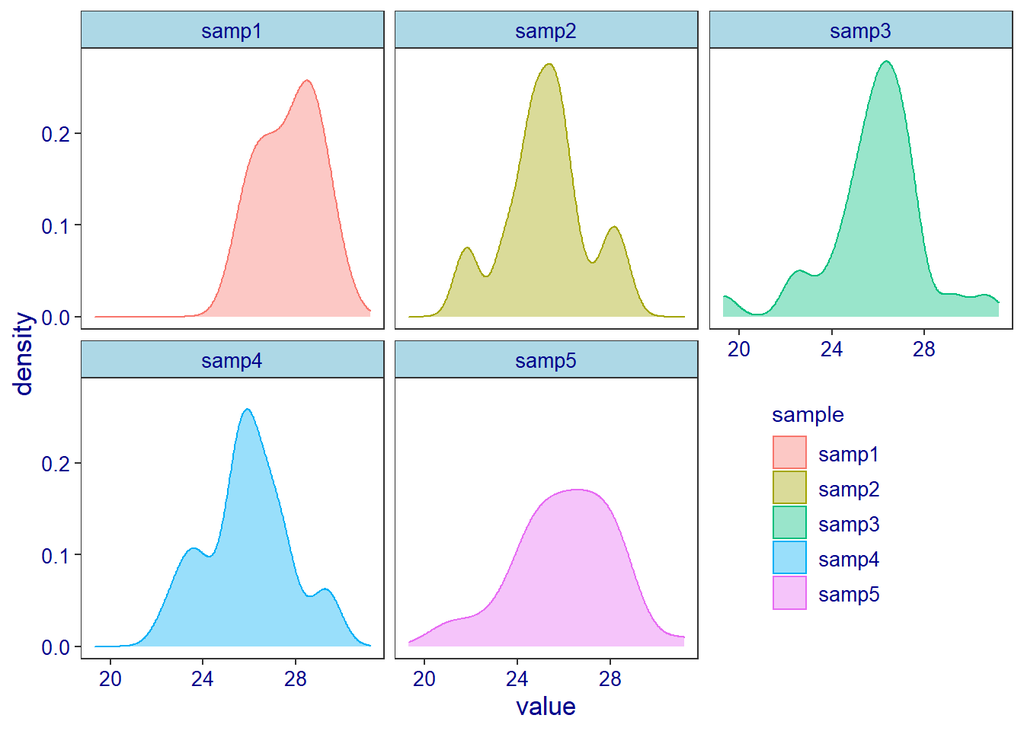

```r
supa %>% ggplot(aes(x = value, colour = sample, fill =sample))+
  geom_density(alpha = 0.4)+ theme_bw()+
  theme(legend.background = element_blank())+
  facet_wrap(~sample)+
  theme(legend.position = c(0.8,0.25),panel.grid = element_line(colour = "white"),axis.title = element_text(colour = "darkblue", size =13),axis.text = element_text(colour = "darkblue", size = 10),strip.background = element_rect(fill = "lightblue"),strip.text.x = element_text(colour = "darkblue", size = 10),legend.text = element_text(colour = "darkblue", size = 10),legend.title = element_text(colour = "darkblue"))
```

The above figure samples now are clearly observed. Also proves the concept that “you are in good position to get right result when you have enough sample”. Therefor you will need to consider the sample size before rushing to analysis.

## The different between Mean and Median

The median is less affected by outliers and skewed data than the mean, and is usually the preferred measure of central tendency, when distribution is not symmetrical.

The mean is usually used for normal distributed data, but median is used for skewed distributions.

## What is the purpose of dispersion

The purpose is to find out how spred out the data values are, on the number line, the deference between the maximum and the minimum value is the formula to measure dispersion (Measure of spread).

## What does it mean by Measure of central tendency

Simply is defined as A measure that identifies a single value as representative of the entire distribution. It is the single value that is most typical/representative of the collected data.

## The mean, Mode and median

1. `**The mean is the average of the data set.**
2. `**The median is the middle of the set of numbers.**
3. ` **The mode is the most common number in a data set.**

In these three the mean is the only one that requires formula. Mean in math is what they call Average, this is because they have the same meaning (they are synonym)

## How to find mean.

There are mainly two ways to find mean in a dataset, One is by finding the sum of the values by adding them all up, dividing the sum by the number of values in the data set.

**Eg. (1,2,3,4,5,6,7) to find mean …… 1+2+3+4+5+6+7= 28/7 = 4 therefor the mean is 4. Remember the mean in a data set does not have to appear in the data set.**

**Eg. (1,2,3,4,5,6,7) to find median ……. you arrange your numbers from the lowest to the highest or from highest to the lowest then you pick the centred number. So in the set 1,2,3,4,5,6,7 the middle number is 4. But what happens if the dataset is like (1,2,3,4,5,6,7,8)?.**

Then in that case you arrange your set as usual the you add the middle numbers and divide by 2 eg 4+5 = 9/2 = 4.5

Mostly the median and the mean are likely to have the same value, even when they differ, not in big gap.

# SAMPLE DATA

```r
trial = iris %>%
  as_tibble() %>%
  janitor::clean_names()
```

```r
trial %$% max(sepal_length, na.rm = TRUE)
```

```
## [1] 7.9
```

```r
trial %$% min(sepal_length, na.rm = TRUE)
```

```
## [1] 4.3
```

```r
trial %$% median(sepal_length, na.rm = TRUE)
```

```
## [1] 5.8
```

```r
trial %$% mean(sepal_length, na.rm = TRUE)
```

```
## [1] 5.843333
```

```r
trial.longer = iris %>%
  as_tibble() %>%
  janitor::clean_names() %>%
  pivot_longer(names_to = "variable", values_to = "value", cols = 1:4)
```

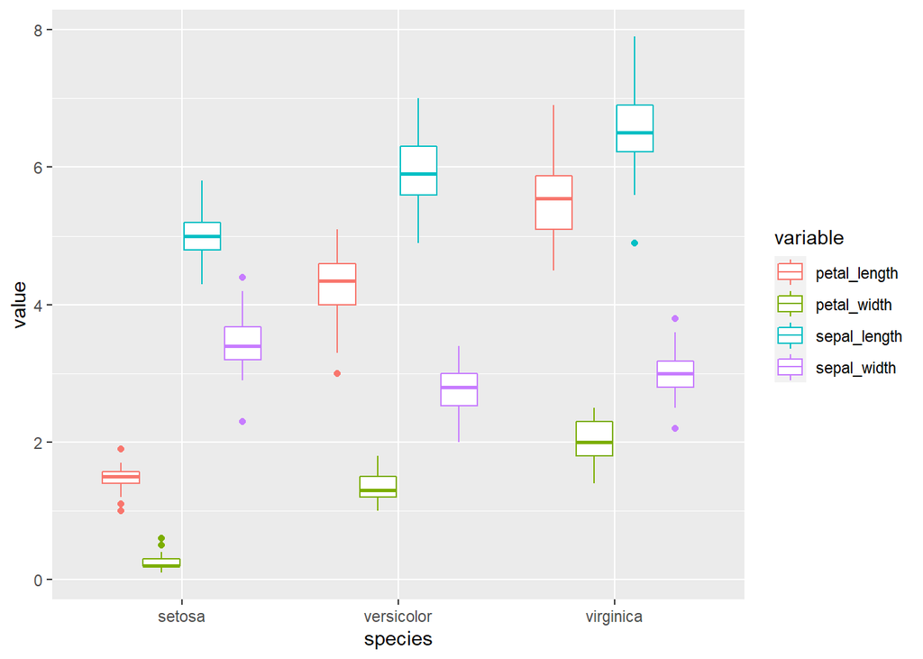

```r
trial.longer %>%
  ggplot(aes(x = species, y = value, color = variable)) +
  geom_boxplot()
```

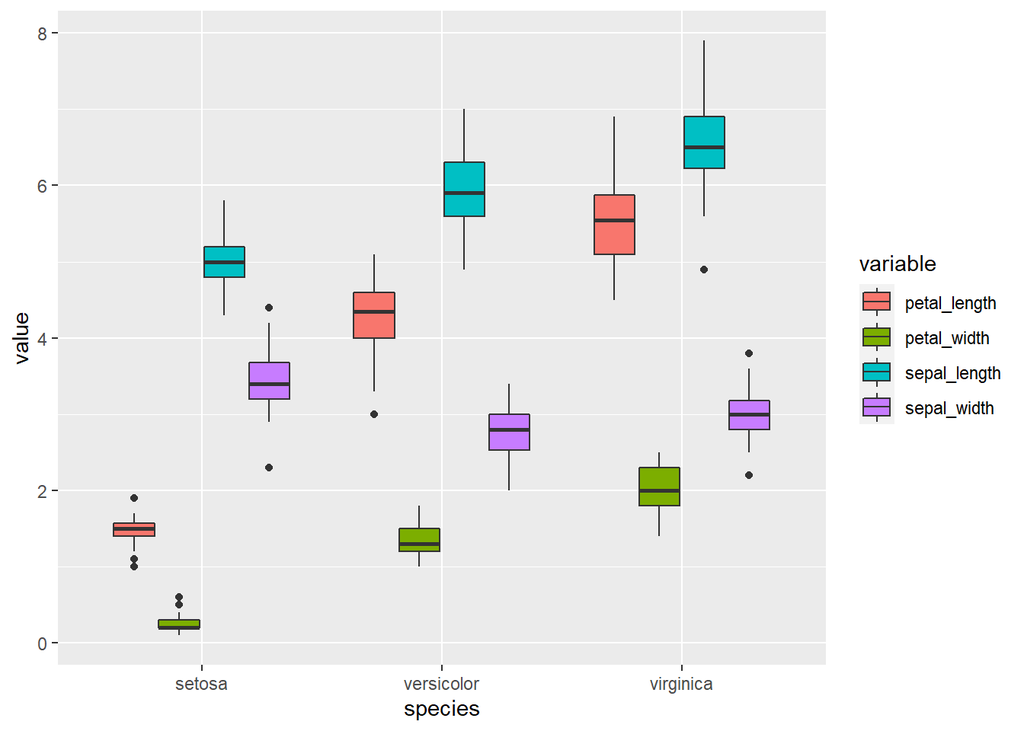

```r
trial.longer %>%
  ggplot(aes(x = species, y = value, fill = variable)) +
  geom_boxplot()
```

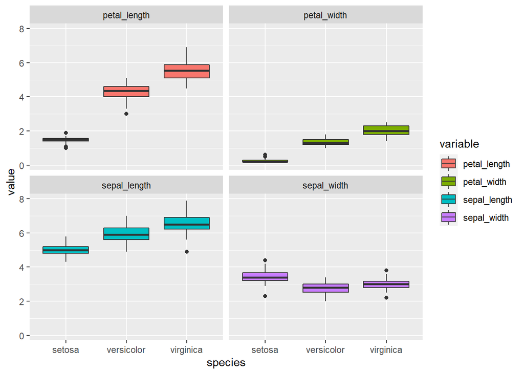

```r
trial.longer %>%
  ggplot(aes(x = species, y = value, fill = variable)) +
  geom_boxplot() +
  facet_wrap(~variable)
```

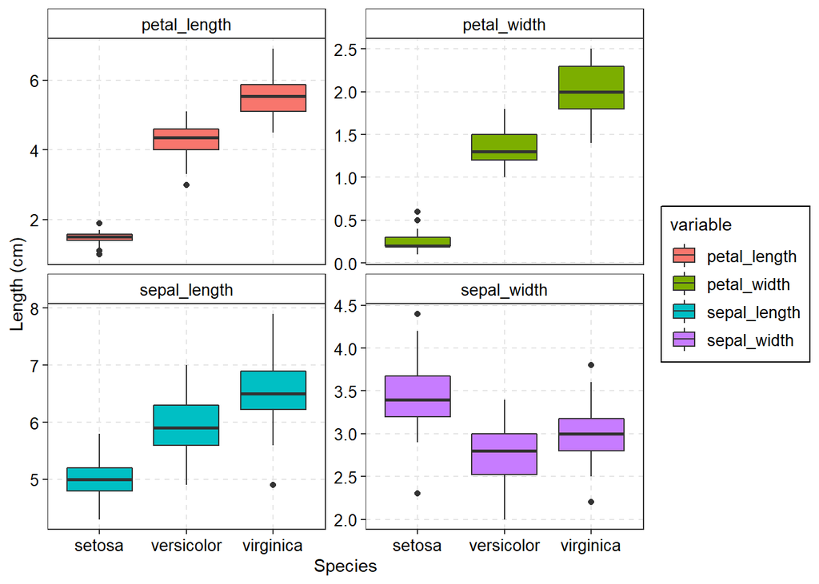

```r
trial.longer %>%
  ggplot(aes(x = species, y = value, fill = variable)) +
  geom_boxplot() +
  facet_wrap(~variable, scales = "free_y") +
  theme_bw() +
  theme(panel.grid.minor.y = element_blank(),
        panel.grid.major = element_line(linetype = "dashed", colour = "grey90"),
        axis.text = element_text(colour = "black", size = 10),
        axis.title = element_text(colour = "black", size = 11),
        legend.background = element_rect(colour = "black", fill = NA),
        legend.text = element_text(colour = "black", size = 10),
        strip.background = element_rect(fill = NA),
        strip.text = element_text(colour = "black", size = 10)) +
  labs(x = "Species", y = "Length (cm)")
```

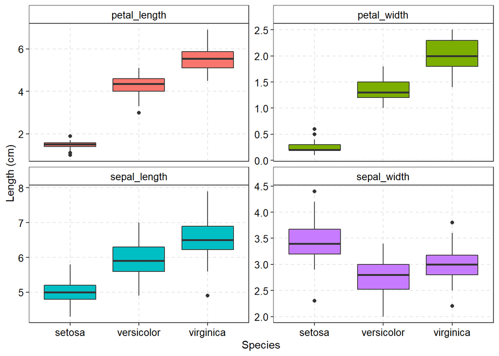

```r
trial.longer %>%
  ggplot(aes(x = species, y = value, fill = variable)) +
  geom_boxplot() +
  facet_wrap(~variable, scales = "free_y") +
  theme_bw() +
  theme(panel.grid.minor.y = element_blank(),
        panel.grid.major = element_line(linetype = "dashed", colour = "grey90"),
        axis.text = element_text(colour = "black", size = 10),
        axis.title = element_text(colour = "black", size = 11),
        legend.position = "none",
        strip.background = element_rect(fill = "NA"),
        strip.text = element_text(colour = "black", size = 10)) +
  labs(x = "Species", y = "Length (cm)")
```

# WORLD POPULATION

**ASSIGNMENT**

Assignment is to find the world’s most popular continent and the most popular country in every continent and the trend of the world population based on data given. The data given is from reliable source of information, data demonstrate the world’s population from 1970 to 2022.

**The package shall be utilized are as follows…**

1. Tidyverse::
2. readr::
3. Lubridate::
4. readxl::
5. magrittr::
6. janitor::
7. dplyr::

**About the chosen package.**

These packages are chosen specifically to handle all activities in this task. Each package functions accordingly. This packages provide several functions that are key tools to facilitate the coding. One can choose the way makes him or her relevant in doing activities in coding. Especially when it comes to package arrangements, firstly understanding of the result required, is usually every coder’s concerns. But how one apply the calling of packages differ from one another.

My self i prefer to call all the package in the very first Chunk, this is because i already know all the neccesary function() i’ll be required to use when coding. So the mentioned package in this assignment are already seted in a firt chunk.

## Data Summary.

The data below requires, to find the most popular continent on Earth, the most popular country on Earth and the general population growth trend. So we are going to import our data in R studio then the next spet is to look weather the data are tidy or not, if **Yes** then we straight move to answer the question and if **Not** then we need to tidy them so that we are able to use them.

## Data Entry.

Data extension is **“csv”** and directory is **e:/MY STAFS/rlanguage/rgenesis/The world population data/world_population.** Therefor after entering them we are going to clean and to visualize them through plotting.

```r
world = read_csv("e:/MY STAFS/rlaguage//The world population data/world_population.csv")
```

```r
pop = world %>%
  clean_names() %>%
  select(-c(1:2, 4, 7:17)) %>%
  rename("population" = 3)
```

```r
con = pop %>% filter(continent == "Asia")

con1 = pop %>% filter(continent == "Africa")

con2 = pop %>% filter(continent == "North America")

con3 = pop %>% filter(continent == "South America")

con4 = pop %>% filter(continent == "Europe")

con5 = pop %>% filter(continent == "Oceania")
```

# CONTINENTS POPULATION.

```r
cont = bind_rows(con, con1, con2, con3, con4, con5)
```

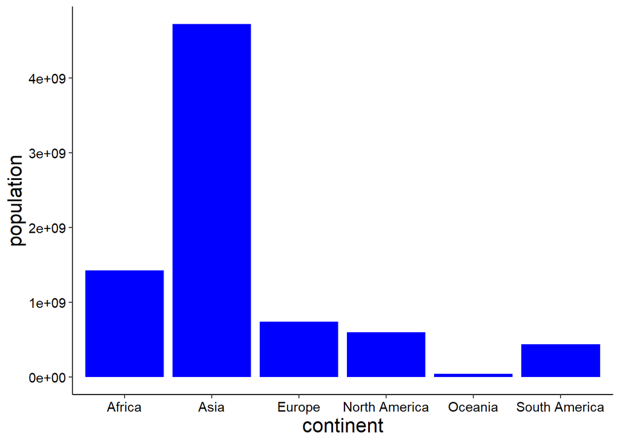

```r
ggplot(data = cont, aes(x = continent, y = population))+
  geom_col(fill = "blue")+
  theme(panel.background = element_rect(fill = 0.4),
        axis.line = element_line(colour = 1, size = 0.4),
        axis.text = element_text(colour = 1, size = 11),
        axis.title = element_text(colour = 17, size = 16))
```

*Finally a graph above demonstrate the world population by continent, the most to miner populated continent on Earth. Asia is leading the chart followed by Africa.*

## ASIA

```r
asia = cont %>% filter(continent == "Asia")
```

```r
asia
```

```
## # A tibble: 50 x 3
##    country     continent population
##    <chr>       <chr>          <dbl>
##  1 Afghanistan Asia        41128771
##  2 Armenia     Asia         2780469
##  3 Azerbaijan  Asia        10358074
##  4 Bahrain     Asia         1472233
##  5 Bangladesh  Asia       171186372
##  6 Bhutan      Asia          782455
##  7 Brunei      Asia          449002
##  8 Cambodia    Asia        16767842
##  9 China       Asia      1425887337
## 10 Georgia     Asia         3744385
## # ... with 40 more rows
```

Tidy and Untidy graph.

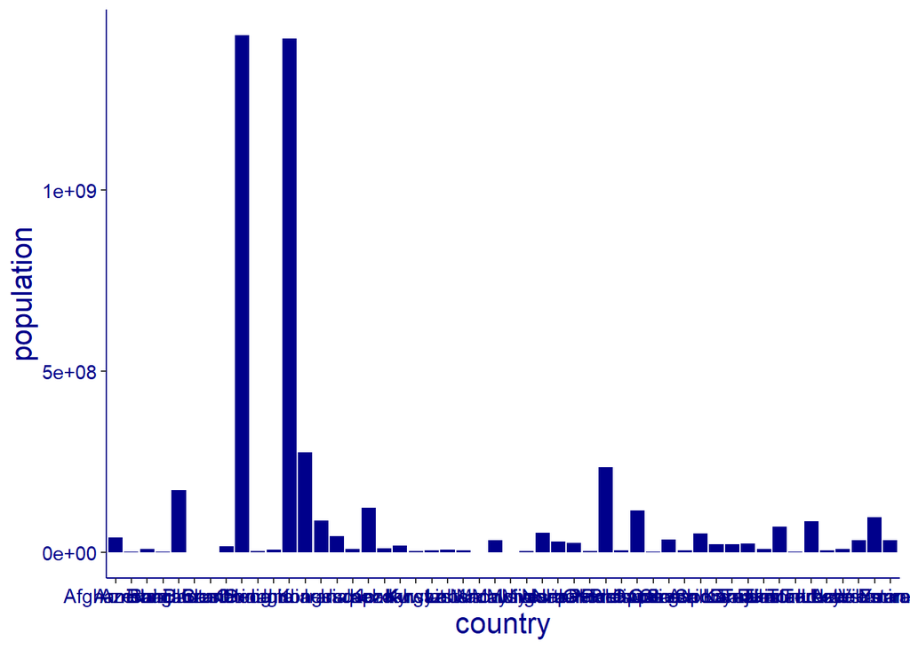

```r
asia %>%
  ggplot(aes(x = country, y = population))+
 geom_col(fill = "dark blue")+
   theme(panel.background = element_rect(fill = 0.4),
        axis.line = element_line(colour = "dark blue", size = 0.4),
        axis.text = element_text(colour = "dark blue", size = 11),
        axis.title = element_text(colour = "dark blue", size = 16),
        legend.key = element_blank())
```

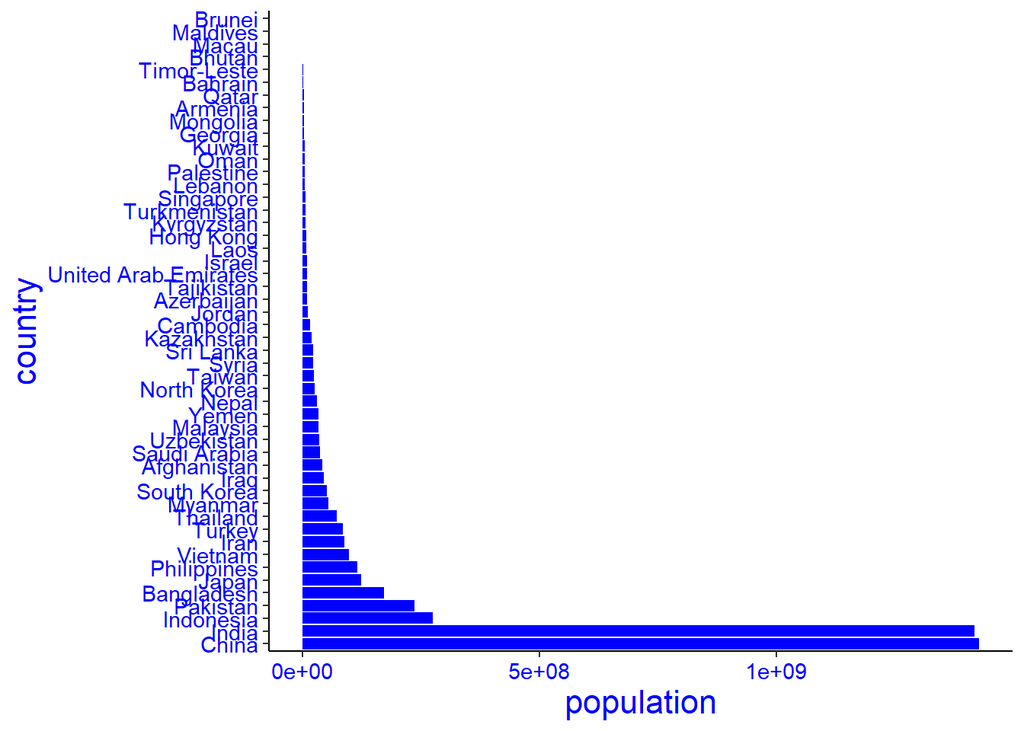

```r
asia %>%
  ggplot(aes(x = country, y = population))+
  geom_col(aes(reorder(x = country, -population)), fill = "blue")+
  coord_flip()+
   theme(panel.background = element_rect(fill = 0.4),
        axis.line = element_line(colour = , size = 0.4),
        axis.text = element_text(colour = "blue", size = 11),
        axis.title = element_text(colour = "blue", size = 16),
         legend.position = "non")
```

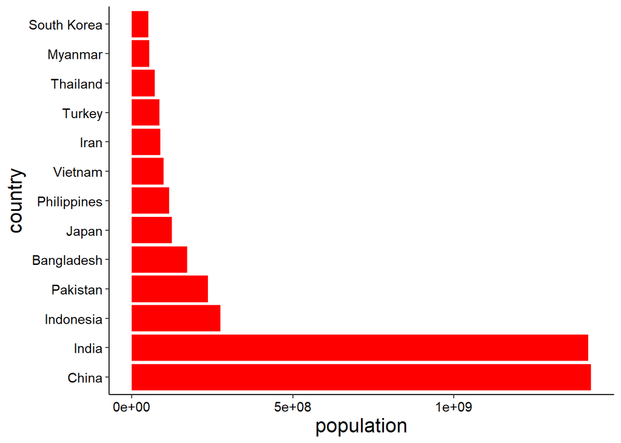

```r
asia %>%
    filter(population >50000000) %>%
  ggplot(aes(x = country, y = population))+
   geom_col(aes(reorder(x = country, -population)), fill = "red")+
  coord_flip()+
   theme(panel.background = element_rect(fill = 0.4),
        axis.line = element_line(colour = 1, size = 0.4),
        axis.text = element_text(colour = 1, size = 11),
        axis.title = element_text(colour = 17, size = 16),
         legend.position = "non")
```

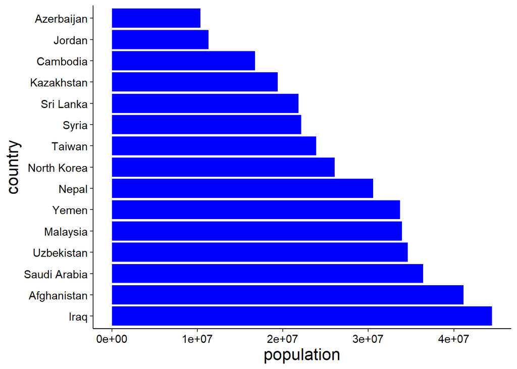

```r
asia %>%
    filter(population >10000000, population <50000000) %>%
  ggplot(aes(x = country, y = population))+
  geom_col(aes(reorder(x = country, -population)), fill = "blue")+
  coord_flip()+
   theme(panel.background = element_rect(fill = 0.4),
        axis.line = element_line(colour = 1, size = 0.4),
        axis.text = element_text(colour = 1, size = 11),
        axis.title = element_text(colour = 17, size = 16),
         legend.position = "non")
```

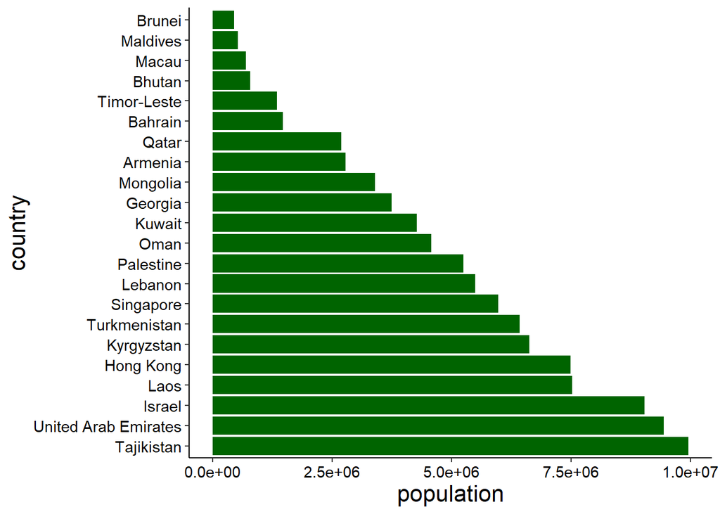

```r
asia %>%
    filter(population <10000000) %>%
  ggplot(aes(x = country, y = population))+
  geom_col(aes(reorder(x = country, -population)), fill = "dark green")+
  coord_flip()+
   theme(panel.background = element_rect(fill = 0.4),
        axis.line = element_line(colour = 1, size = 0.4),
        axis.text = element_text(colour = 1, size = 11),
        axis.title = element_text(colour = 17, size = 16),
         legend.position = "non")
```

*Therefor The Red graph shows countries with population more than Fifty millions, The Blue graph shows countries with population between Ten to Fifty millions, While the green graph shows the countries with less than Ten millions.*

*The second tp fourth graph does allow the reader’s eyes to relax when reading the counties names, therefor we have to flip our graph so that the names of the countries can be well viwed, we use the function Coord_flip() of the package tidyverse.*

## AFRICA

```r
africa = bind_rows(con, con1, con2, con3, con4, con5) %>%
  filter(continent == "Africa")
```

```r
africa
```

```
## # A tibble: 57 x 3
##    country                  continent population
##    <chr>                    <chr>          <dbl>
##  1 Algeria                  Africa      44903225
##  2 Angola                   Africa      35588987
##  3 Benin                    Africa      13352864
##  4 Botswana                 Africa       2630296
##  5 Burkina Faso             Africa      22673762
##  6 Burundi                  Africa      12889576
##  7 Cameroon                 Africa      27914536
##  8 Cape Verde               Africa        593149
##  9 Central African Republic Africa       5579144
## 10 Chad                     Africa      17723315
## # ... with 47 more rows
```

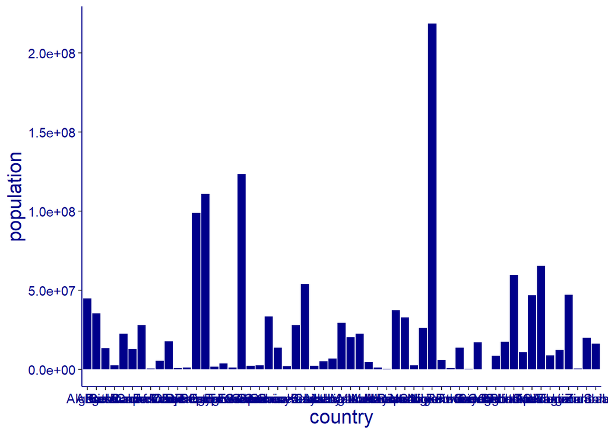

```r
africa %>%
  ggplot(aes(x = country, y = population))+
 geom_col(fill = "dark blue")+
   theme(panel.background = element_rect(fill = 0.4),
        axis.line = element_line(colour = "dark blue", size = 0.4),
        axis.text = element_text(colour = "dark blue", size = 11),
        axis.title = element_text(colour = "dark blue", size = 16),
        legend.key = element_blank())
```

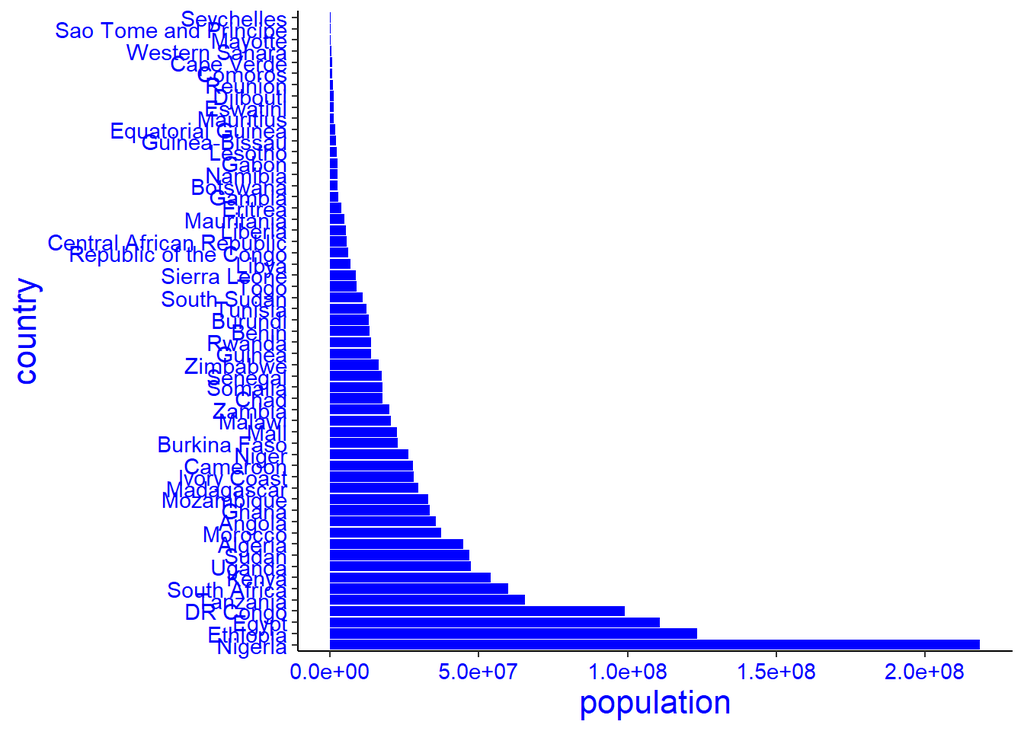

```r
africa %>%
  ggplot(aes(x = country, y = population))+
   geom_col(aes(reorder(x = country, -population)), fill = "blue")+
  coord_flip()+
   theme(panel.background = element_rect(fill = 0.4),
        axis.line = element_line(colour = , size = 0.4),
        axis.text = element_text(colour = "blue", size = 11),
        axis.title = element_text(colour = "blue", size = 16),
         legend.position = "non")
```

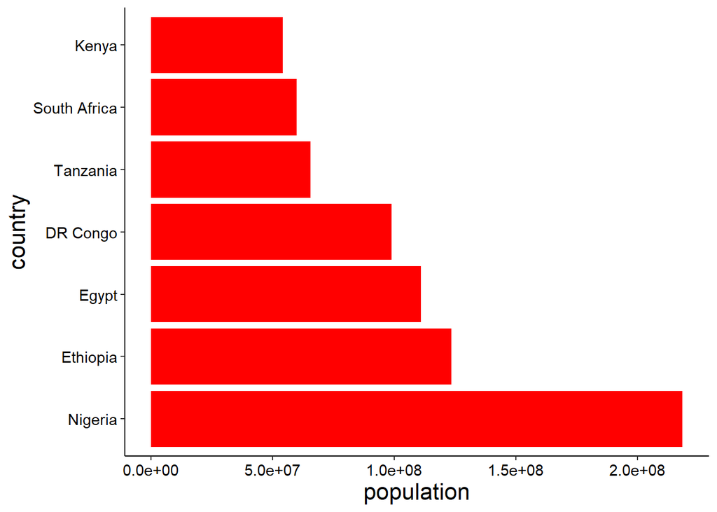

```r
africa %>%
  filter(population >50000000) %>%
  ggplot(aes(x = country, y = population))+
  geom_col(aes(reorder(x = country, -population)), fill = "red")+
  coord_flip()+
   theme(panel.background = element_rect(fill = 0.4),
        axis.line = element_line(colour = 1, size = 0.4),
        axis.text = element_text(colour = 1, size = 11),
        axis.title = element_text(colour = 17, size = 16),
         legend.position = "non")
```